# A brief comparison of speed of Interior Point and EM algorithms

Matthew Stephens

2016-01-26

**Last updated:** 2017-01-17

**Code version:** efcd39d916a87f7322f9c515c668905c36a86f9a

First, we load the necessary libraries.

```r
library(REBayes)
```

```r
library(ashr)
library(ggplot2)
```

## Set up simulation

The following simulation assumes $\beta \sim N(0,\sigma_{\sf betasd}^2)$ and with $\hat{\beta}$ having standard deviation 1.

```r
timed_sims = function(ash.args,nsim = 20,nmin = 100,nmax = 1e3,betasd = 1) {
  n = 10^seq(log10(nmin),log10(nmax),length = nsim)
  elapsed.time = rep(0,nsim)
  for (i in 1:nsim) {
    set.seed(i)
    with(ash.args,cat(sprintf("%6s %13s %3d\n",method,optmethod,i)))
    betahat = rnorm(n[i],sd = sqrt(1 + betasd^2))
    elapsed.time[i] =
      system.time(do.call(ash,args = modifyList(ash.args,
        list(betahat = betahat, sebetahat = 1))))[3]
  }
  return(data.frame(elapsed.time = elapsed.time,seed = 1:nsim,n = n))
}
```

Now run a simulation study, for $n$ (number of tests; $p$ in paper) in range 10 to 100,000. Note that the warnings are being generated by the EM algorithm in big problems due to lack of convergence.

```r
df = data.frame()
cat("method --optmethod-- sim\n")
for(method in c("fdr","shrink")) {
  for(optmethod in c("mixIP","cxxMixSquarem")) {
    df = rbind(df,data.frame(method = method,optmethod = optmethod,
           timed_sims(list(method = method,optmethod = optmethod),
                           nsim = 50,nmin = 10,nmax = 1e5)))
  }
}
```

[output not shown]

[output cut: 20 more lines]

[output not shown]

```r
cat("\n")
```

Summarize the model fitting results in a table.

```r
cat("Average computation time (in seconds):\n")
```

```
Average computation time (in seconds):
```

```r
print(as.table(by(df,df[c("method","optmethod")],
                  function (x) mean(x$elapsed.time))))
```

```
        optmethod
method    mixIP cxxMixSquarem
  fdr     6.800        23.699
  shrink  5.972        27.931
```

## Results

Now plot time as a function of $n$:

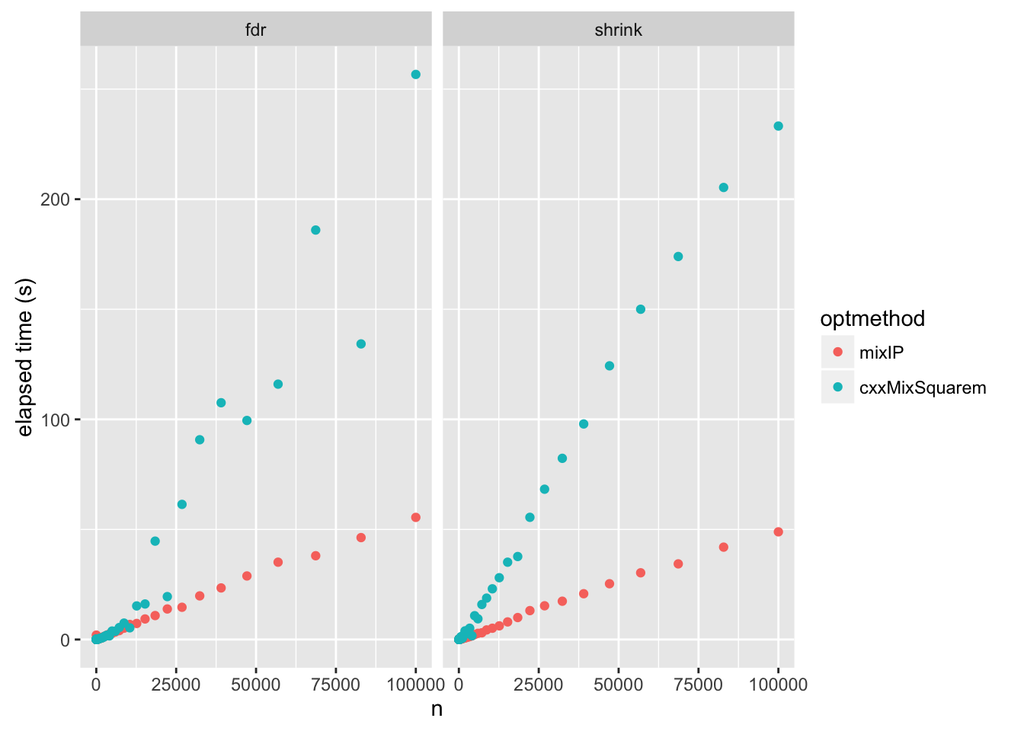

```r
qplot(x = n,y = elapsed.time,data = df,col = optmethod,facets = .~method,
      ylab = "elapsed time (s)")
```

Zoom-in on “small” problems with $n < 5000$.

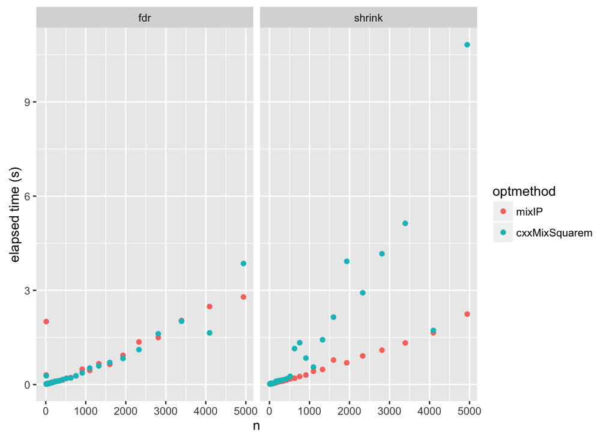

```r
qplot(x = n,y = elapsed.time, data = subset(df,n < 5000),
      col = optmethod,facets = .~method,ylab = "elapsed time (s)")
```

## Summary

The IP method clearly scales to large problem much better than EM. It is faster, and also more reliable (sometimes reaches higher log-likelihood than EM, never smaller); see checkIP.html.

However, for small problems (n < 5000) the EM is adequate for many practical purposes, solving within a few seconds. This is particularly true for the penalty term (method = fdr), which helps the EM converge, presumably because it is helping identifiability, removing the large flat parts of the likelihood objective function.

Indeed, for small problems with the penalty term (n < 2000) EM with squarem acceleration is a little faster in these comparisons than IP.